# Analysis of Streaming Transactions

Based on Data Collected by SportsTV

Kanad Motiwale

# 1 Executive Summary

This report analyzes streaming transactions for SportsTV Germany, covering January 06, 2021 through October 16, 2025. The analysis includes **996,091** total streaming events across **4** countries featuring **3** sports.

**Data Quality Handling:** The ETL process filtered out transactions with NULL values in critical fields (date, sport, country, or duration). From 1.18 million raw records, 996,091 valid transactions were loaded, representing high-quality data suitable for analysis. All fact table records maintain referential integrity with zero NULL values.

# 2 Growth of Streaming Transactions Over Time

## 2.1 Analysis by Sport

This section examines the growth trends in streaming activity across different sports over all available years.

Table 1: Streaming Activity by Year and Sport

| Year | Sport | Total Streaming Events | Total Streaming Minutes |
| --- | --- | --- | --- |
| 2,021 | Ice Hockey | 3,892 | 294,300 |
| 2,021 | Inline Hockey | 2,905 | 215,307 |
| 2,021 | Ski Jumping | 3,801 | 338,289 |
| 2,022 | Ice Hockey | 19,031 | 1,429,111 |
| 2,022 | Inline Hockey | 12,809 | 959,737 |
| 2,022 | Ski Jumping | 21,088 | 1,897,102 |
| 2,023 | Ice Hockey | 46,650 | 3,508,448 |
| 2,023 | Inline Hockey | 31,835 | 2,382,250 |
| 2,023 | Ski Jumping | 57,461 | 5,160,241 |
| 2,024 | Ice Hockey | 109,087 | 8,195,758 |
| 2,024 | Inline Hockey | 71,949 | 5,392,203 |
| 2,024 | Ski Jumping | 129,819 | 11,690,196 |
| 2,025 | Ice Hockey | 167,445 | 12,578,485 |
| 2,025 | Inline Hockey | 107,259 | 8,052,391 |
| 2,025 | Ski Jumping | 211,060 | 19,005,937 |

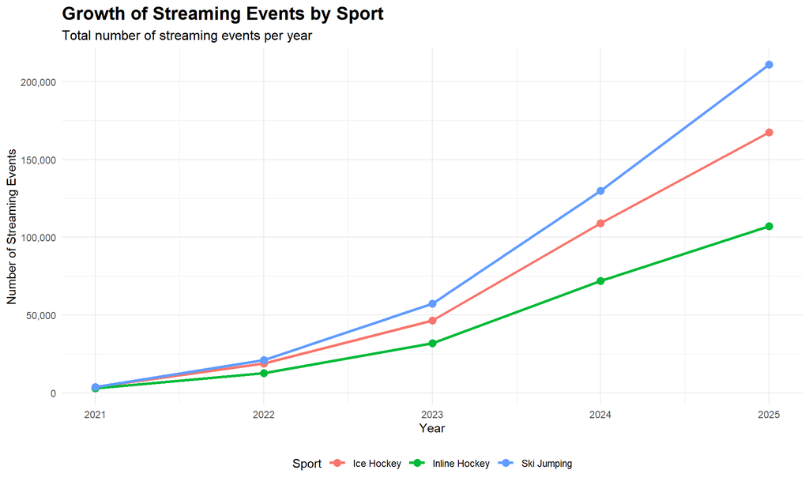

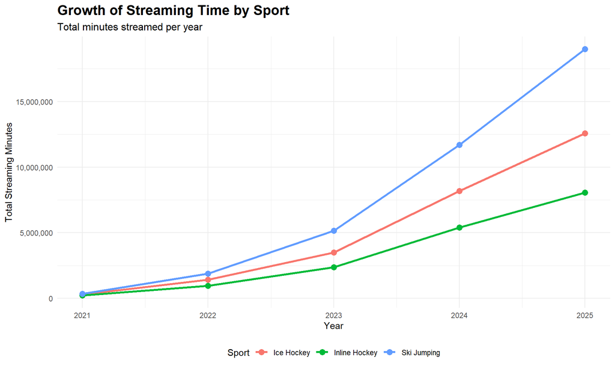

### 2.1.1 Key Findings

- Streaming events grew by **56.3%** from 2024 to 2025
- **Ski Jumping** is the most streamed sport with **423,229** total streaming events across all years

# 3 Weekly Streaming Patterns

## 3.1 Most Recent Year Analysis

This section examines weekly streaming patterns for the most recent year of data.

Table 2: Weekly Streaming Events in 2025

| Week Number | Total Streaming Events |
| --- | --- |
| 0 | 5,235 |
| 1 | 9,148 |
| 2 | 9,190 |
| 3 | 9,252 |
| 4 | 9,481 |
| 5 | 9,415 |
| 6 | 9,523 |
| 7 | 9,768 |
| 8 | 9,717 |
| 9 | 9,940 |
| 10 | 9,985 |
| 11 | 9,935 |
| 12 | 10,087 |
| 13 | 10,175 |
| 14 | 10,167 |
| 15 | 10,439 |
| 16 | 10,543 |
| 17 | 10,818 |
| 18 | 10,718 |
| 19 | 10,576 |
| 20 | 11,099 |
| 21 | 11,183 |
| 22 | 11,191 |
| 23 | 11,400 |
| 24 | 11,275 |
| 25 | 11,876 |
| 26 | 12,011 |
| 27 | 12,090 |
| 28 | 12,464 |
| 29 | 12,127 |
| 30 | 13,050 |
| 31 | 13,113 |
| 32 | 13,204 |
| 33 | 13,467 |
| 34 | 14,088 |
| 35 | 14,228 |
| 36 | 15,096 |
| 37 | 15,696 |
| 38 | 16,325 |
| 39 | 17,175 |
| 40 | 17,225 |
| 41 | 12,269 |

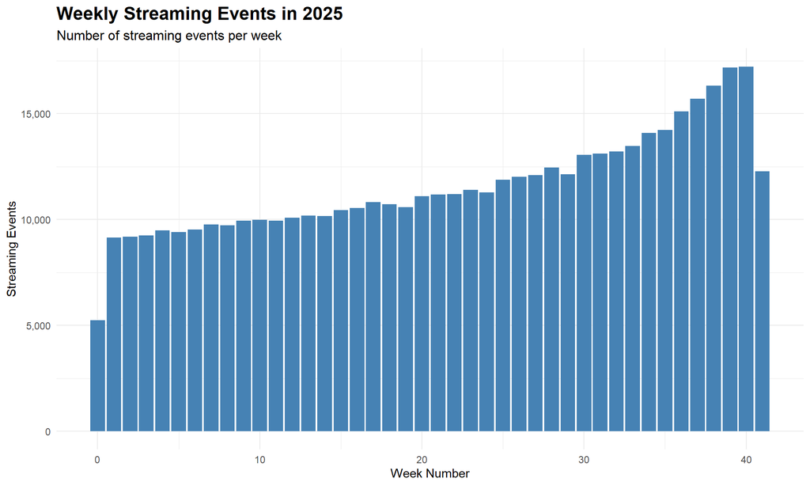

### 3.1.1 Weekly Statistics

- Average weekly streaming events: **11,566**
- Peak week: Week **40** with **17,225** events
- Lowest week: Week **0** with **5,235** events

# 4 Streaming Analytics by Sport and Country

## 4.1 Average Streaming Time and Total Streams

Table 3: Streaming Metrics by Sport and Country

| Sport | Country | Total Streams | Avg Minutes per Stream |
| --- | --- | --- | --- |
| Ice Hockey | Deutschland | 117,178 | 75.58 |
| Ice Hockey | Italy | 692 | 78.48 |
| Ice Hockey | Österreich | 115,591 | 75.09 |
| Ice Hockey | Schweiz | 112,644 | 75.24 |
| Inline Hockey | Deutschland | 71,358 | 75.22 |
| Inline Hockey | Österreich | 84,485 | 74.81 |
| Inline Hockey | Schweiz | 70,914 | 74.69 |
| Ski Jumping | Deutschland | 149,157 | 89.75 |
| Ski Jumping | Österreich | 174,997 | 89.93 |
| Ski Jumping | Schweiz | 99,075 | 89.16 |

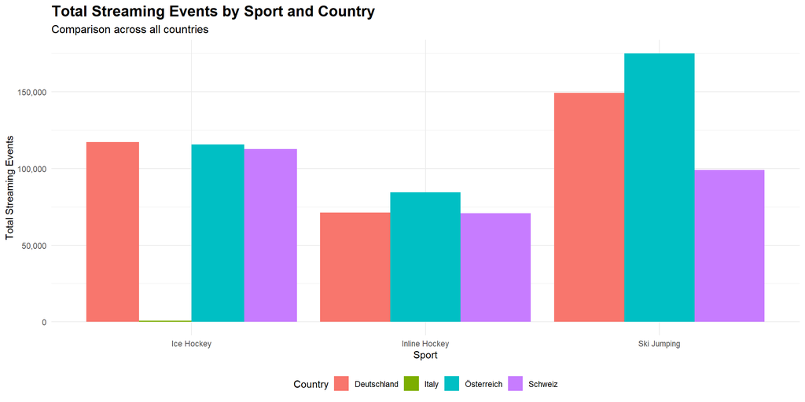

# 5 Day of Week Analysis

## 5.1 Peak Streaming Days by Sport and Country

This analysis identifies which day of the week has the highest streaming activity (by total minutes) over the past three years.

Table 4: Peak Streaming Day by Sport and Country (2023-2025)

| Sport | Country | Peak Day | Total Minutes Streamed |
| --- | --- | --- | --- |
| Ice Hockey | Deutschland | Monday | 1,182,264 |
| Inline Hockey | Deutschland | Monday | 725,527 |
| Ski Jumping | Deutschland | Tuesday | 1,837,038 |
| Ice Hockey | Italy | Sunday | 9,007 |
| Ice Hockey | Österreich | Friday | 1,190,782 |
| Inline Hockey | Österreich | Tuesday | 859,549 |
| Ski Jumping | Österreich | Saturday | 2,151,918 |
| Ice Hockey | Schweiz | Saturday | 1,149,439 |
| Inline Hockey | Schweiz | Thursday | 708,358 |
| Ski Jumping | Schweiz | Thursday | 1,199,224 |

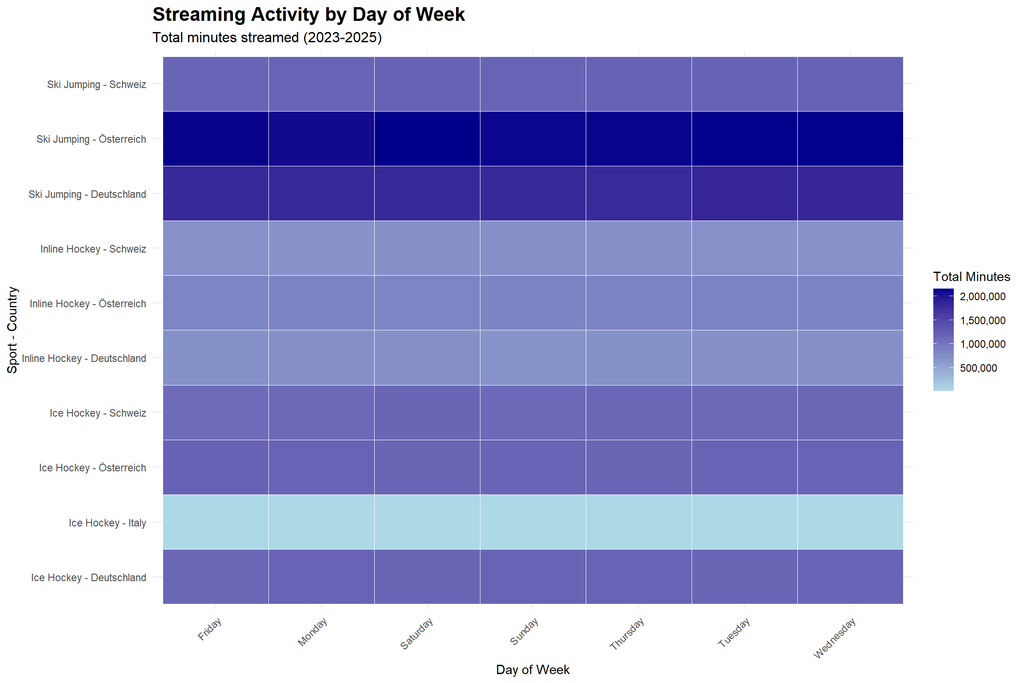

# 6 Conclusion

The data demonstrates consistent growth in streaming activity across all sports, with distinct patterns by geography and day of week. These insights can inform content acquisition strategies, marketing campaigns, and infrastructure planning.